# Regression and model validation

*Describe the work you have done this week and summarize your learning.*

- Describe your work and results clearly.
- Assume the reader has an introductory course level understanding of writing and reading R code as well as statistical methods
- Assume the reader has no previous knowledge of your data or the more advanced methods you are using

**This week focuses on data wrangling, regression analysis and model validation, In a survey, some questions were asked to understand the students’ approaches used in learning. Based on these, the following variables were extracted: gender, age, examination points, strategic approach, deep learning approach, attitude and surface learning approach.**

**The result of my analysis showed that there were about two times more female students respondents than their male counterparts. Overall, attitude seems to be the most determining factor towards the success of students in their examination. Strategic learning approach also seems to contribute to some extent to the success. While age showed a very low negative effect, it cannot be concluded to be a major factor as most of the respondents were young students below 26.**

**To validate my model, I used the QQ plot, residual vs fitted and residuals vs leverage. In making choice of my predictor variables, I examined the standard error, Multiple R squared(coefficient of determination) and the p value to check the significance of variables. ggpairs() function also came in handy when getting a broad overview of the distribution of the variables.**

```r
#read the students2014 data

lrn14<- read.table("C:/Users/oyeda/Desktop/OPEN_DATA_SCIENCE/IODS-project/data/learning2014.txt ", header=T, sep = "\t")

#Alternatively, I could also read the already wrangled data as below:
#lrn14<- read.table("http://s3.amazonaws.com/assets.datacamp.com/production/co#urse_2218/datasets/learning2014.txt ", header=T, sep = ",")


#structure of the data
str(lrn14)
```

```
## 'data.frame':    166 obs. of  7 variables:
##  $ deep    : num  3.58 2.92 3.5 3.5 3.67 4.75 3.83 3.25 4.33 4 ...
##  $ surf    : num  2.58 3.17 2.25 2.25 2.83 2.42 1.92 2.83 2.17 3 ...
##  $ stra    : num  3.38 2.75 3.62 3.12 3.62 3.62 2.25 4 4.25 3.5 ...
##  $ age     : int  53 55 49 53 49 38 50 37 37 42 ...
##  $ attitude: num  3.7 3.1 2.5 3.5 3.7 3.8 3.5 2.9 3.8 2.1 ...
##  $ points  : int  25 12 24 10 22 21 21 31 24 26 ...
##  $ gender  : Factor w/ 2 levels "F","M": 1 2 1 2 2 1 2 1 2 1 ...
```

```r
#dimension of the data
dim(lrn14)
```

```
## [1] 166   7
```

The data includes 7 variables which describes several attributes of students:

- age : Age (in years) derived from the date of birth
- attitude: Global attitude toward statistics -points: Exam points
- gender: Gender: M (Male), F (Female)
- deep: Deep Approach
- surf: Surface approach
- stra: Strategic approach

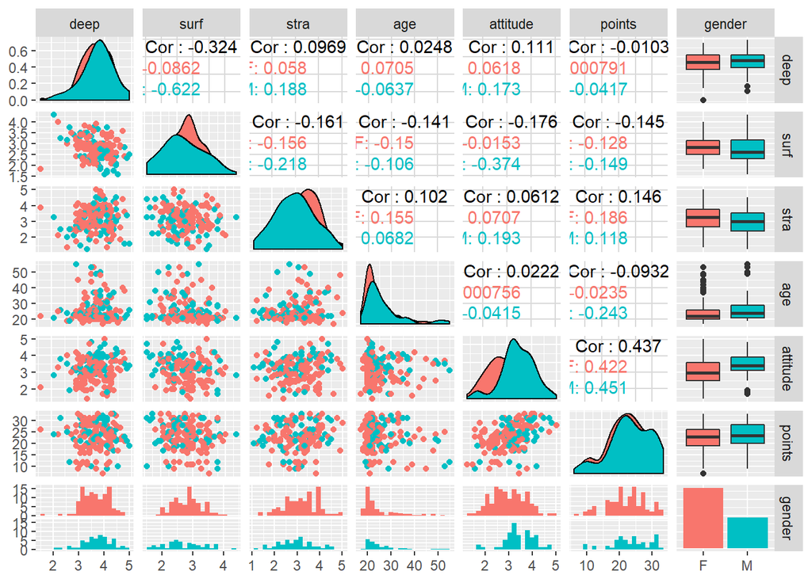

```r
#load ggplot2
library(ggplot2)
#install.packages("GGally")
library(GGally)
ggpairs(lrn14, aes(col=gender), lower = list(combo = wrap("facethist", bins = 20)))
```

```r
summary(lrn14)
```

```
##       deep           surf            stra            age
##  Min.   :1.58   Min.   :1.580   Min.   :1.250   Min.   :17.00
##  1st Qu.:3.33   1st Qu.:2.420   1st Qu.:2.620   1st Qu.:21.00
##  Median :3.67   Median :2.830   Median :3.185   Median :22.00
##  Mean   :3.68   Mean   :2.787   Mean   :3.121   Mean   :25.51
##  3rd Qu.:4.08   3rd Qu.:3.170   3rd Qu.:3.620   3rd Qu.:27.00
##  Max.   :4.92   Max.   :4.330   Max.   :5.000   Max.   :55.00
##     attitude         points      gender
##  Min.   :1.400   Min.   : 7.00   F:110
##  1st Qu.:2.600   1st Qu.:19.00   M: 56
##  Median :3.200   Median :23.00
##  Mean   :3.143   Mean   :22.72
##  3rd Qu.:3.700   3rd Qu.:27.75
##  Max.   :5.000   Max.   :33.00
```

```r
#By and large, we have almost twice as much female responsdent out of 166 students
#aside those with examination point 0. The average age is about 26 years with
#the youngest being 17 years and an old student of age 55. The ages of the
#respondents are mainly skewed to the right, showing they are mostly young students
#below 26 years. We can also see from the box plot that the age the age is non-normal
#and skewed to the right with some outliers. The attitude, points and deep learning approach
#also have few outliers. Generally, the pairs show weak correaltions. However,
#attitude seems to be the most strongly correlated(although still weak) with points, for b
#male and female. Men generally seem to have a slightly better attitude than their
#female counterpart. although, some male students show very poor attitude towards learning.
#Both genders also appear to have average to very deep learning approach.
#Female students have a slightly better strategic approach. However, there appears to
#be not much distinctions between examinations points of male and female students.
#Most students seem to have more above average score while a few students showed very
#poor performance.


#Choose three variables as explanatory variables and fit a regression model
#where exam points is the target (dependent) variable. Show a summary of
#the fitted model and comment and interpret the results. Explain and interpret
#the statistical test related to the model parameters. If an explanatory
#variable in your model does not have a statistically significant relationship
#with the target variable, remove the variable from the model and fit the model
#again without it. (0-4 points)

#I attempted to use all the variables for the model and stepwise regression
#to help remove the redundant variables.
l_model<-lm(points~gender+age+attitude+deep+stra+surf, data = lrn14)
summary(l_model)
```

```
##
## Call:
## lm(formula = points ~ gender + age + attitude + deep + stra +
##     surf, data = lrn14)
##
## Residuals:
##      Min       1Q   Median       3Q      Max
## -17.4513  -3.2513   0.3836   3.5240  11.4869
##
## Coefficients:
##             Estimate Std. Error t value Pr(>|t|)
## (Intercept) 18.32352    5.25571   3.486 0.000633 ***
## genderM     -0.06009    0.92983  -0.065 0.948551
## age         -0.09606    0.05396  -1.780 0.076916 .
## attitude     3.44426    0.59775   5.762 4.19e-08 ***
## deep        -1.04826    0.78408  -1.337 0.183155
## stra         0.95823    0.55156   1.737 0.084271 .
## surf        -1.11001    0.84433  -1.315 0.190519
## ---
## Signif. codes:  0 '***' 0.001 '**' 0.01 '*' 0.05 '.' 0.1 ' ' 1
##
## Residual standard error: 5.265 on 159 degrees of freedom
## Multiple R-squared:  0.2312, Adjusted R-squared:  0.2022
## F-statistic: 7.971 on 6 and 159 DF,  p-value: 1.588e-07
```

```r
library(MASS)
mm<-stepAIC(l_model, direction = "both")
```

```
## Start:  AIC=558.34
## points ~ gender + age + attitude + deep + stra + surf
##
##            Df Sum of Sq    RSS    AIC
## - gender    1      0.12 4408.0 556.35
## - surf      1     47.91 4455.8 558.14
## - deep      1     49.55 4457.5 558.20
## <none>                  4407.9 558.34
## - stra      1     83.67 4491.6 559.46
## - age       1     87.88 4495.8 559.62
## - attitude  1    920.43 5328.3 587.82
##
## Step:  AIC=556.35
## points ~ age + attitude + deep + stra + surf
##
##            Df Sum of Sq    RSS    AIC
## - surf      1     47.82 4455.8 556.14
## - deep      1     49.66 4457.7 556.21
## <none>                  4408.0 556.35
## - stra      1     88.28 4496.3 557.64
## - age       1     90.18 4498.2 557.71
## + gender    1      0.12 4407.9 558.34
## - attitude  1    999.58 5407.6 588.27
##
## Step:  AIC=556.14
## points ~ age + attitude + deep + stra
##
##            Df Sum of Sq    RSS    AIC
## - deep      1     27.03 4482.9 555.14
## <none>                  4455.8 556.14
## + surf      1     47.82 4408.0 556.35
## - age       1     75.38 4531.2 556.92
## - stra      1    106.09 4561.9 558.04
## + gender    1      0.02 4455.8 558.14
## - attitude  1   1085.20 5541.0 590.32
##
## Step:  AIC=555.14
## points ~ age + attitude + stra
##
##            Df Sum of Sq    RSS    AIC
## <none>                  4482.9 555.14
## - age       1     76.60 4559.5 555.95
## + deep      1     27.03 4455.8 556.14
## + surf      1     25.19 4457.7 556.21
## - stra      1     97.54 4580.4 556.71
## + gender    1      0.01 4482.9 557.14
## - attitude  1   1061.20 5544.1 588.41
```

```r
#After using stepwise regression, I ended up with three explanatory variables namely:
#'age','attitude' and 'stra'

#now, let's refit the model with these three variables
l_model2<-lm(points ~ age + attitude + stra, data = lrn14)
summary(l_model2)
```

```
##
## Call:
## lm(formula = points ~ age + attitude + stra, data = lrn14)
##
## Residuals:
##      Min       1Q   Median       3Q      Max
## -18.1199  -3.2006   0.3307   3.4131  10.7605
##
## Coefficients:
##             Estimate Std. Error t value Pr(>|t|)
## (Intercept) 10.89473    2.64895   4.113 6.20e-05 ***
## age         -0.08821    0.05302  -1.664   0.0981 .
## attitude     3.48143    0.56219   6.193 4.69e-09 ***
## stra         1.00324    0.53436   1.877   0.0623 .
## ---
## Signif. codes:  0 '***' 0.001 '**' 0.01 '*' 0.05 '.' 0.1 ' ' 1
##
## Residual standard error: 5.26 on 162 degrees of freedom
## Multiple R-squared:  0.2182, Adjusted R-squared:  0.2037
## F-statistic: 15.07 on 3 and 162 DF,  p-value: 1.072e-08
```

```r
#As shown by the model, the p value of 'attitude' is very low below 0.05 and with
#higher confidence that 'attitude' significantly affects the examination points.
#However, the coeffient of determination(Multiple R-squared) of the model is just (0.2182)21.82% which is
#relatively low. The standard error of age is quite low and p value is not
#so high either. Hence, this can be incorporated into the model.
#However, even though, the standard error of strategic approach is relatively high with 0.53
#compared with age with 0.05, the p-value is lower. Based on this, I will remove the age because it is less significant.
#Finally, I am left with predictors; 'attitude' and 'strategic approach'.
#age seems to have a slightly negative effect while attitude and strategic approach has a positive effect.
#Just as points and age showed a low negative correlation earlier, it can be seen that
#age has a slight negative effect(-0.08821) on the examination poitns while attitude, which
#showed slightly higher positive correlation with points earlier, has  a positive
#effect(3.48143) on the examination points

#Final model
lm_final<-lm(points~stra+attitude, data = lrn14)
summary(lm_final)
```

```
##
## Call:
## lm(formula = points ~ stra + attitude, data = lrn14)
##
## Residuals:
##      Min       1Q   Median       3Q      Max
## -17.6482  -3.3135   0.5571   3.7966  10.9300
##
## Coefficients:
##             Estimate Std. Error t value Pr(>|t|)
## (Intercept)   8.9725     2.3966   3.744 0.000251 ***
## stra          0.9132     0.5345   1.709 0.089438 .
## attitude      3.4664     0.5652   6.134 6.27e-09 ***
## ---
## Signif. codes:  0 '***' 0.001 '**' 0.01 '*' 0.05 '.' 0.1 ' ' 1
##
## Residual standard error: 5.289 on 163 degrees of freedom
## Multiple R-squared:  0.2048, Adjusted R-squared:  0.195
## F-statistic: 20.99 on 2 and 163 DF,  p-value: 7.746e-09
```

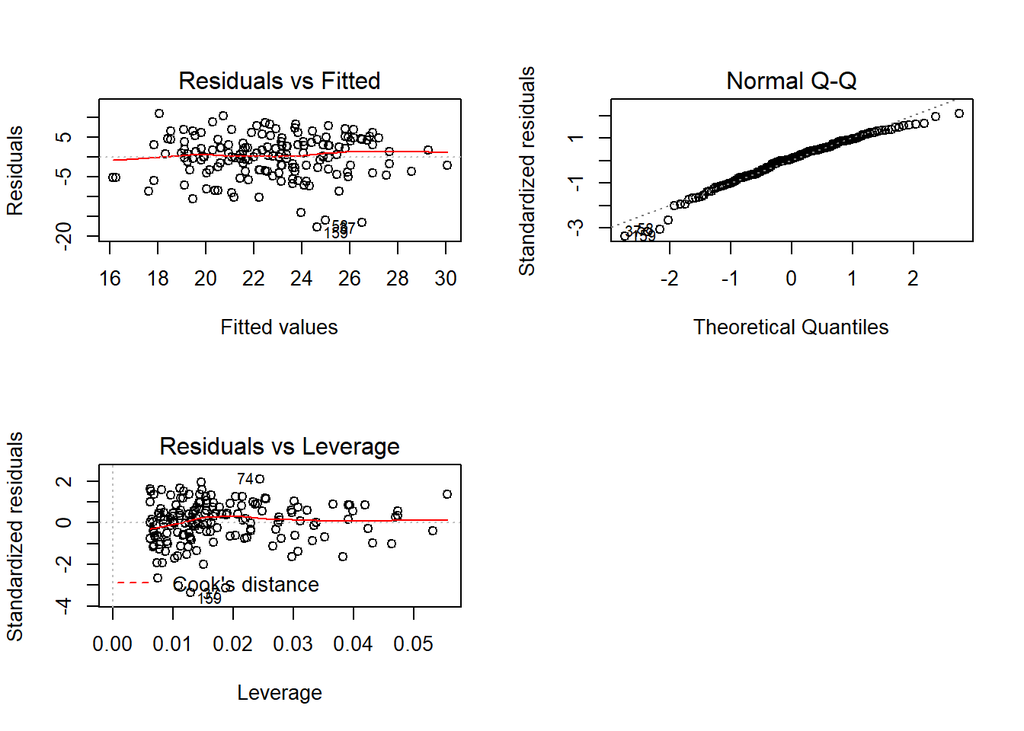

```r
#Although, the coefficient of determination(Multiple R-Squared) reduced slightly to 20.48% from 21.82%
#and the standard error only increased from 5.26 to 5.289. The difference difference
#is not so drastic. The p-value is also well below 0.05.
#with the 'ättitude' and 'strategeic approach', I got a higher Multiple R-squared of 0.2048 compared to
#0.2011 when I used age and attitude. Thus, I decided to use 'attitude' and 'strategic approach'.

par(mfrow=c(2,2))
plot(lm_final, which = c(1,2,5))

#As seen in the Normal Q-Q plot, the points fit well to the line, aside few deviations
#at the beginning and end. The errors can thus, be said to be normally distributed.
#for the residuals vs fitted, it can be seen that there is a slight change as the values inceas.
#However, no observation seems to have clear leverage over others.
```